# 388_Project_House Prices_Haiting You

Haiting You

Nov 24th 2018

# 1.Introduction

## 1.1.Background

This is a housing dataset with 79 explanatory variables describing (almost) every aspect of residential homes in Ames, Iowa. We want to use this dataset to predict the sales prices in dollars(SalePrice) for each house.

## 1.2.Data Description

### 1.2.1.Data Preparation

Loading the data from the train and test dataset, combining them into one dataset, with the purpose to keep them consistent in the following analysis.

```r
#load the data
train<-read.csv("E:/Loyola/Fall 2018/STAT 388 001 Predictive Analytics/Project/houseprices/train.csv",header=TRUE)
#head(train)
train$group<-1
test<-read.csv("E:/Loyola/Fall 2018/STAT 388 001 Predictive Analytics/Project/houseprices/test.csv",header=TRUE)
#head(test)
test$SalePrice<-0
test$group<-2
#combine the data to make sure the type of the data is consistant.
house<-rbind(train,test)
head(house)
```

|  | Id | MSSubClass | MSZoning | LotFrontage | LotArea | Street | Alley | LotShape | LandContour | Utilities | LotConfig | LandSlope | Neighborhood | Condition1 | Condition2 | BldgType | HouseStyle | OverallQual | OverallCond | YearBuilt | YearRemodAdd | RoofStyle | RoofMatl | Exterior1st | Exterior2nd | MasVnrType | MasVnrArea | ExterQual | ExterCond | … |
| --- | --- | --- | --- | --- | --- | --- | --- | --- | --- | --- | --- | --- | --- | --- | --- | --- | --- | --- | --- | --- | --- | --- | --- | --- | --- | --- | --- | --- | --- | --- |
| 1 | 1 | 60 | RL | 65 | 8450 | Pave | NA | Reg | Lvl | AllPub | Inside | Gtl | CollgCr | Norm | Norm | 1Fam | 2Story | 7 | 5 | 2003 | 2003 | Gable | CompShg | VinylSd | VinylSd | BrkFace | 196 | Gd | TA | … |
| 2 | 2 | 20 | RL | 80 | 9600 | Pave | NA | Reg | Lvl | AllPub | FR2 | Gtl | Veenker | Feedr | Norm | 1Fam | 1Story | 6 | 8 | 1976 | 1976 | Gable | CompShg | MetalSd | MetalSd | None | 0 | TA | TA | … |
| 3 | 3 | 60 | RL | 68 | 11250 | Pave | NA | IR1 | Lvl | AllPub | Inside | Gtl | CollgCr | Norm | Norm | 1Fam | 2Story | 7 | 5 | 2001 | 2002 | Gable | CompShg | VinylSd | VinylSd | BrkFace | 162 | Gd | TA | … |
| 4 | 4 | 70 | RL | 60 | 9550 | Pave | NA | IR1 | Lvl | AllPub | Corner | Gtl | Crawfor | Norm | Norm | 1Fam | 2Story | 7 | 5 | 1915 | 1970 | Gable | CompShg | Wd Sdng | Wd Shng | None | 0 | TA | TA | … |
| 5 | 5 | 60 | RL | 84 | 14260 | Pave | NA | IR1 | Lvl | AllPub | FR2 | Gtl | NoRidge | Norm | Norm | 1Fam | 2Story | 8 | 5 | 2000 | 2000 | Gable | CompShg | VinylSd | VinylSd | BrkFace | 350 | Gd | TA | … |
| 6 | 6 | 50 | RL | 85 | 14115 | Pave | NA | IR1 | Lvl | AllPub | Inside | Gtl | Mitchel | Norm | Norm | 1Fam | 1.5Fin | 5 | 5 | 1993 | 1995 | Gable | CompShg | VinylSd | VinylSd | None | 0 | TA | TA | … |

```r
str(house)
```

```
'data.frame':   2919 obs. of  82 variables:
 $ Id           : int  1 2 3 4 5 6 7 8 9 10 ...
 $ MSSubClass   : int  60 20 60 70 60 50 20 60 50 190 ...
 $ MSZoning     : Factor w/ 5 levels "C (all)","FV",..: 4 4 4 4 4 4 4 4 5 4 ...
 $ LotFrontage  : int  65 80 68 60 84 85 75 NA 51 50 ...
 $ LotArea      : int  8450 9600 11250 9550 14260 14115 10084 10382 6120 7420 ...
 $ Street       : Factor w/ 2 levels "Grvl","Pave": 2 2 2 2 2 2 2 2 2 2 ...
 $ Alley        : Factor w/ 2 levels "Grvl","Pave": NA NA NA NA NA NA NA NA NA NA ...
 $ LotShape     : Factor w/ 4 levels "IR1","IR2","IR3",..: 4 4 1 1 1 1 4 1 4 4 ...
 $ LandContour  : Factor w/ 4 levels "Bnk","HLS","Low",..: 4 4 4 4 4 4 4 4 4 4 ...
 $ Utilities    : Factor w/ 2 levels "AllPub","NoSeWa": 1 1 1 1 1 1 1 1 1 1 ...
 $ LotConfig    : Factor w/ 5 levels "Corner","CulDSac",..: 5 3 5 1 3 5 5 1 5 1 ...
 $ LandSlope    : Factor w/ 3 levels "Gtl","Mod","Sev": 1 1 1 1 1 1 1 1 1 1 ...
 $ Neighborhood : Factor w/ 25 levels "Blmngtn","Blueste",..: 6 25 6 7 14 12 21 17 18 4 ...
 $ Condition1   : Factor w/ 9 levels "Artery","Feedr",..: 3 2 3 3 3 3 3 5 1 1 ...
```

[output cut: 68 more lines]

```r
summary(house)
```

```
       Id           MSSubClass        MSZoning     LotFrontage        LotArea
 Min.   :   1.0   Min.   : 20.00   C (all):  25   Min.   : 21.00   Min.   :  1300
 1st Qu.: 730.5   1st Qu.: 20.00   FV     : 139   1st Qu.: 59.00   1st Qu.:  7478
 Median :1460.0   Median : 50.00   RH     :  26   Median : 68.00   Median :  9453
 Mean   :1460.0   Mean   : 57.14   RL     :2265   Mean   : 69.31   Mean   : 10168
 3rd Qu.:2189.5   3rd Qu.: 70.00   RM     : 460   3rd Qu.: 80.00   3rd Qu.: 11570
 Max.   :2919.0   Max.   :190.00   NA's   :   4   Max.   :313.00   Max.   :215245
                                                  NA's   :486
  Street      Alley      LotShape   LandContour  Utilities      LotConfig
 Grvl:  12   Grvl: 120   IR1: 968   Bnk: 117    AllPub:2916   Corner : 511
 Pave:2907   Pave:  78   IR2:  76   HLS: 120    NoSeWa:   1   CulDSac: 176
             NA's:2721   IR3:  16   Low:  60    NA's  :   2   FR2    :  85
                         Reg:1859   Lvl:2622                  FR3    :  14
                                                              Inside :2133


 LandSlope   Neighborhood    Condition1     Condition2     BldgType      HouseStyle
 Gtl:2778   NAmes  : 443   Norm   :2511   Norm   :2889   1Fam  :2425   1Story :1471
 Mod: 125   CollgCr: 267   Feedr  : 164   Feedr  :  13   2fmCon:  62   2Story : 872
 Sev:  16   OldTown: 239   Artery :  92   Artery :   5   Duplex: 109   1.5Fin : 314
            Edwards: 194   RRAn   :  50   PosA   :   4   Twnhs :  96   SLvl   : 128
            Somerst: 182   PosN   :  39   PosN   :   4   TwnhsE: 227   SFoyer :  83
            NridgHt: 166   RRAe   :  28   RRNn   :   2                 2.5Unf :  24
            (Other):1428   (Other):  35   (Other):   2                 (Other):  27
  OverallQual      OverallCond      YearBuilt     YearRemodAdd    RoofStyle
 Min.   : 1.000   Min.   :1.000   Min.   :1872   Min.   :1950   Flat   :  20
 1st Qu.: 5.000   1st Qu.:5.000   1st Qu.:1954   1st Qu.:1965   Gable  :2310
 Median : 6.000   Median :5.000   Median :1973   Median :1993   Gambrel:  22
 Mean   : 6.089   Mean   :5.565   Mean   :1971   Mean   :1984   Hip    : 551
 3rd Qu.: 7.000   3rd Qu.:6.000   3rd Qu.:2001   3rd Qu.:2004   Mansard:  11
 Max.   :10.000   Max.   :9.000   Max.   :2010   Max.   :2010   Shed   :   5

    RoofMatl     Exterior1st    Exterior2nd     MasVnrType     MasVnrArea
 CompShg:2876   VinylSd:1025   VinylSd:1014   BrkCmn :  25   Min.   :   0.0
 Tar&Grv:  23   MetalSd: 450   MetalSd: 447   BrkFace: 879   1st Qu.:   0.0
 WdShake:   9   HdBoard: 442   HdBoard: 406   None   :1742   Median :   0.0
 WdShngl:   7   Wd Sdng: 411   Wd Sdng: 391   Stone  : 249   Mean   : 102.2
 ClyTile:   1   Plywood: 221   Plywood: 270   NA's   :  24   3rd Qu.: 164.0
 Membran:   1   (Other): 369   (Other): 390                  Max.   :1600.0
 (Other):   2   NA's   :   1   NA's   :   1                  NA's   :23
```

[output cut: 72 more lines]

```
    MiscVal             MoSold           YrSold        SaleType    SaleCondition
 Min.   :    0.00   Min.   : 1.000   Min.   :2006   WD     :2525   Abnorml: 190
 1st Qu.:    0.00   1st Qu.: 4.000   1st Qu.:2007   New    : 239   AdjLand:  12
 Median :    0.00   Median : 6.000   Median :2008   COD    :  87   Alloca :  24
 Mean   :   50.83   Mean   : 6.213   Mean   :2008   ConLD  :  26   Family :  46
 3rd Qu.:    0.00   3rd Qu.: 8.000   3rd Qu.:2009   CWD    :  12   Normal :2402
 Max.   :17000.00   Max.   :12.000   Max.   :2010   (Other):  29   Partial: 245
                                                    NA's   :   1
   SalePrice          group
 Min.   :     0   Min.   :1.0
 1st Qu.:     0   1st Qu.:1.0
 Median : 34900   Median :1.0
 Mean   : 90492   Mean   :1.5
 3rd Qu.:163000   3rd Qu.:2.0
 Max.   :755000   Max.   :2.0
```

**From the summary, some types of the variables are wrong. Besides there are many NA values in both train dataset and test dataset.We need check them before modeling.**

#### a).Suitable type of variables problem

Some variables should be treated as factor. The rule of whether to be a factor is that “Is 2 twice as many as 1 here”. So for number of rooms,such as the variables of BsmtFullBath and FullBath, 2 is definitely twice as many as 1, then we will not transfer them to factor. But for the rating, we should transfer to factor.

```r
#change to factor
#2.MSSubClass: Identifies the type of dwelling involved in the sale. should be catergorical data
#18.OverallQual:Rates the overall material and finish of the house(1-10)
#19.OverallCond: Rates the overall condition of the house(1-10)
#77.MoSold: Month Sold (MM),change to factor
#78.YrSold: only 6 years
vector1<-c(2,18,19,77,78)
for (i in vector1) {
 house[,i]<-as.factor(house[,i])
}
str(house[,vector1])
```

```
'data.frame':   2919 obs. of  5 variables:
 $ MSSubClass : Factor w/ 16 levels "20","30","40",..: 6 1 6 7 6 5 1 6 5 16 ...
 $ OverallQual: Factor w/ 10 levels "1","2","3","4",..: 7 6 7 7 8 5 8 7 7 5 ...
 $ OverallCond: Factor w/ 9 levels "1","2","3","4",..: 5 8 5 5 5 5 5 6 5 6 ...
 $ MoSold     : Factor w/ 12 levels "1","2","3","4",..: 2 5 9 2 12 10 8 11 4 1 ...
 $ YrSold     : Factor w/ 5 levels "2006","2007",..: 3 2 3 1 3 4 2 4 3 3 ...
```

#### b).NA problem: Not exsist rather than missing, change to NotExist or 0

```r
#change to NotExist
#7.Alley:NA(No alley access), change to NotExist
#31.BsmtQual: Evaluates the height of the basement,37 are NA(No Basement),change to NotExist
#32.BsmtCond:37 are NA(No Basement),change to NotExist
#33.BsmtExposure:No(No Exposure)  NA(38 are No Basement,but actually is 37 have no basement, one of them are missing),change to NotExist
#34.BsmtFinType1: Rating of basement finished,37 of them are NA (No Basement),change to NotExist
#36.BsmtFinType2: Rating of basement finished area NA(38 are No Basement,but actually is 37 have no basement, one of them are missing),change to NotExist
#58.FireplaceQu: Fireplace quality, 690 NA(No Fireplace),change to NotExist
#59.GarageType: Garage location, 81 NA(No Garage),change to NotExist
#61.GarageFinish: 81 NA(No Garage),change to NotExist
#64.GarageQual: Garage quality, 81 NA(No Garage),change to NotExist
#65.GarageCond: Garage condition, 81 NA(No Garage),change to NotExist
#73.PoolQC:NA(No Pool), 1453 NA,change to NotExist
#74.Fence:NA(no Fence),1179NA, change to NotExist
#75.MiscFeature: 1406NA, change to NotExist
vector2<-c(7,31:34,36,58,59,61,64:65,73:75)
for (i in vector2) {
#check levels
levels(house[,i])
#add new factor level. i.e "NotExist"
house[,i] = factor(house[,i], levels=c(levels(house[,i]),"NotExist"))
#convert all NA's to "NotExist"
house[,i][is.na(house[,i])] ="NotExist"#house[is.na(house)] #find out all the missing value
#check levels again
#levels(house[,i])
}
summary(house[,vector2])
```

```
      Alley          BsmtQual        BsmtCond      BsmtExposure    BsmtFinType1
 Grvl    : 120   Ex      : 258   Fa      : 104   Av      : 418   ALQ     :429
 Pave    :  78   Fa      :  88   Gd      : 122   Gd      : 276   BLQ     :269
 NotExist:2721   Gd      :1209   Po      :   5   Mn      : 239   GLQ     :849
                 TA      :1283   TA      :2606   No      :1904   LwQ     :154
                 NotExist:  81   NotExist:  82   NotExist:  82   Rec     :288
                                                                 Unf     :851
                                                                 NotExist: 79
   BsmtFinType2    FireplaceQu      GarageType     GarageFinish     GarageQual
 ALQ     :  52   Ex      :  43   2Types  :  23   Fin     : 719   Ex      :   3
 BLQ     :  68   Fa      :  74   Attchd  :1723   RFn     : 811   Fa      : 124
 GLQ     :  34   Gd      : 744   Basment :  36   Unf     :1230   Gd      :  24
 LwQ     :  87   Po      :  46   BuiltIn : 186   NotExist: 159   Po      :   5
 Rec     : 105   TA      : 592   CarPort :  15                   TA      :2604
 Unf     :2493   NotExist:1420   Detchd  : 779                   NotExist: 159
 NotExist:  80                   NotExist: 157
    GarageCond        PoolQC          Fence        MiscFeature
 Ex      :   3   Ex      :   4   GdPrv   : 118   Gar2    :   5
 Fa      :  74   Fa      :   2   GdWo    : 112   Othr    :   4
 Gd      :  15   Gd      :   4   MnPrv   : 329   Shed    :  95
 Po      :  14   NotExist:2909   MnWw    :  12   TenC    :   1
 TA      :2654                   NotExist:2348   NotExist:2814
 NotExist: 159
```

```r
#change to 0 if there are none
#27.MasVnrArea: 864 obs of the MasVnrType is none, so here 869 missing could change to 0
#39.TotalBsmtSF: Total square feet of basement area,37 are NA(No Basement),change to 0
#63.GarageArea: 81 NA(No Garage),change to 0
#76.MiscVal: $Value of miscellaneous feature, 1408 NA, but 2 of them are truely missing, change to 0
#60.GarageYrBlt:  81 NA(No Garage),change to 0
vector3<-c(27,39,60,63,76)
for (i in vector3) {
house[,i][is.na(house[,i])] =0
}
summary(house[,vector3])
```

```
   MasVnrArea      TotalBsmtSF    GarageYrBlt     GarageArea        MiscVal
 Min.   :   0.0   Min.   :   0   Min.   :   0   Min.   :   0.0   Min.   :    0.00
 1st Qu.:   0.0   1st Qu.: 793   1st Qu.:1957   1st Qu.: 320.0   1st Qu.:    0.00
 Median :   0.0   Median : 989   Median :1977   Median : 480.0   Median :    0.00
 Mean   : 101.4   Mean   :1051   Mean   :1870   Mean   : 472.7   Mean   :   50.83
 3rd Qu.: 163.5   3rd Qu.:1302   3rd Qu.:2001   3rd Qu.: 576.0   3rd Qu.:    0.00
 Max.   :1600.0   Max.   :6110   Max.   :2207   Max.   :1488.0   Max.   :17000.00
```

### 1.2.2.Missing value

```r
#find the missing columns
NAcol <- which(colSums(is.na(house)) > 0)
sort(colSums(sapply(house[NAcol], is.na)), decreasing = TRUE)
```

```
 LotFrontage   MasVnrType     MSZoning    Utilities BsmtFullBath BsmtHalfBath
         486           24            4            2            2            2
  Functional  Exterior1st  Exterior2nd   BsmtFinSF1   BsmtFinSF2    BsmtUnfSF
           2            1            1            1            1            1
  Electrical  KitchenQual   GarageCars     SaleType
           1            1            1            1
```

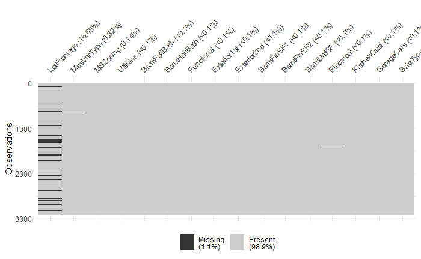

```r
#Visualization of the missing value
# sort the rows
#visdat::vis_miss(house, sort_miss = TRUE)
# visualise the number of missings in each variable using naniar `gg_miss_var`
#naniar::gg_miss_var(house)
library(dplyr)
missingvalue <- house%>%select(MSZoning,LotFrontage,Utilities,Exterior1st,Exterior2nd,MasVnrType,BsmtFinSF1,BsmtFinSF2,BsmtUnfSF,Electrical,BsmtFullBath,BsmtHalfBath,Functional,KitchenQual,GarageCars,SaleType)
visdat::vis_miss(missingvalue, sort_miss = TRUE)
```

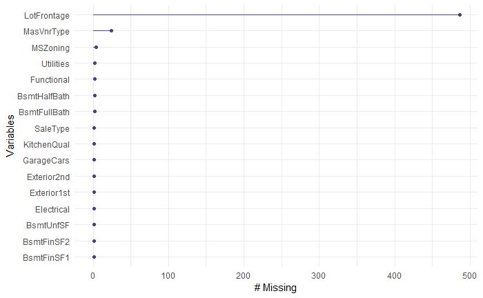

```r
# visualise the number of missings in each variable using naniar `gg_miss_var`
naniar::gg_miss_var(missingvalue)
```

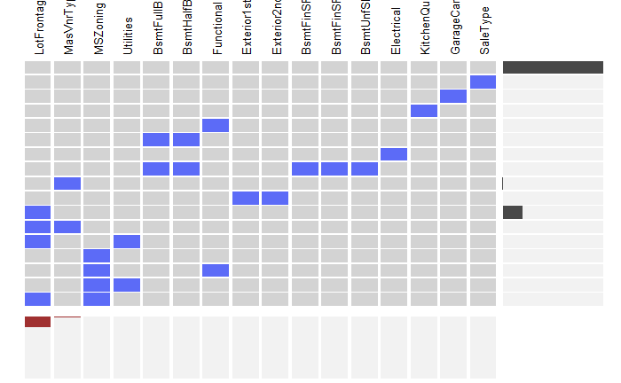

```r
# sort by columns
extracat::visna(missingvalue, sort = "c")
```

**For the missing value, we may impute the missing value: with the median value or the prediction from linear model(numerical data) or logistic model (categorical data).**

```r
#impute the mising data
#replace the missing value with the median value,as they are only few missing value(continous variable)
#35.BsmtFinSF1
#37.BsmtFinSF2
#38.BsmtUnfSF
#48.BsmtFullBath
#49.BsmtHalfBath
#62.GarageCars
vector4<-c(35,37,38,48,49,62)
for (i in vector4){
house[which(is.na(house[,i])),][,i]<-median(house[which(!is.na(house[,i])),][,i])#median(house$BsmtFinSF1[which(!is.na(house[,35]))])
}
#impute with most frequency levels
#3.MSZoning
#10.Utilities will drop this column
#24.Exterior1st
#25.Exterior2nd
#26.MasVnrType
#43.Electrical
#54.KitchenQual
#56.Functional
#79.SaleType
vector5<-c(3,24,25,26,43,54,56,79)
for (i in vector5){
df<-data.frame(table(house[,i]))
house[which(is.na(house[,i])),][,i]<-df[which.max(df$Freq),]$Var1
}
#replace the missing value of LotFrontage with the predicted value
#4.LotFrontage
library(rpart)
Lot <- rpart(LotFrontage ~., data=house[!is.na(house$LotFrontage),], method="anova", na.action=na.omit)
lot_pred<- predict(Lot, house[is.na(house$LotFrontage),])
house$LotFrontage[is.na(house$LotFrontage)]<-round(lot_pred,0)
summary(house$LotFrontage)
```

```
   Min. 1st Qu.  Median    Mean 3rd Qu.    Max.
  21.00   60.00   69.00   69.97   81.00  313.00
```

```r
summary(house)
```

```
       Id           MSSubClass      MSZoning     LotFrontage        LotArea
 Min.   :   1.0   20     :1079   C (all):  25   Min.   : 21.00   Min.   :  1300
 1st Qu.: 730.5   60     : 575   FV     : 139   1st Qu.: 60.00   1st Qu.:  7478
 Median :1460.0   50     : 287   RH     :  26   Median : 69.00   Median :  9453
 Mean   :1460.0   120    : 182   RL     :2269   Mean   : 69.97   Mean   : 10168
 3rd Qu.:2189.5   30     : 139   RM     : 460   3rd Qu.: 81.00   3rd Qu.: 11570
 Max.   :2919.0   70     : 128                  Max.   :313.00   Max.   :215245
                  (Other): 529
  Street          Alley      LotShape   LandContour  Utilities      LotConfig
 Grvl:  12   Grvl    : 120   IR1: 968   Bnk: 117    AllPub:2916   Corner : 511
 Pave:2907   Pave    :  78   IR2:  76   HLS: 120    NoSeWa:   1   CulDSac: 176
             NotExist:2721   IR3:  16   Low:  60    NA's  :   2   FR2    :  85
                             Reg:1859   Lvl:2622                  FR3    :  14
                                                                  Inside :2133


 LandSlope   Neighborhood    Condition1     Condition2     BldgType      HouseStyle
 Gtl:2778   NAmes  : 443   Norm   :2511   Norm   :2889   1Fam  :2425   1Story :1471
 Mod: 125   CollgCr: 267   Feedr  : 164   Feedr  :  13   2fmCon:  62   2Story : 872
 Sev:  16   OldTown: 239   Artery :  92   Artery :   5   Duplex: 109   1.5Fin : 314
            Edwards: 194   RRAn   :  50   PosA   :   4   Twnhs :  96   SLvl   : 128
            Somerst: 182   PosN   :  39   PosN   :   4   TwnhsE: 227   SFoyer :  83
            NridgHt: 166   RRAe   :  28   RRNn   :   2                 2.5Unf :  24
            (Other):1428   (Other):  35   (Other):   2                 (Other):  27
  OverallQual   OverallCond     YearBuilt     YearRemodAdd    RoofStyle
 5      :825   5      :1645   Min.   :1872   Min.   :1950   Flat   :  20
 6      :731   6      : 531   1st Qu.:1954   1st Qu.:1965   Gable  :2310
 7      :600   7      : 390   Median :1973   Median :1993   Gambrel:  22
 8      :342   8      : 144   Mean   :1971   Mean   :1984   Hip    : 551
 4      :226   4      : 101   3rd Qu.:2001   3rd Qu.:2004   Mansard:  11
 9      :107   3      :  50   Max.   :2010   Max.   :2010   Shed   :   5
 (Other): 88   (Other):  58
    RoofMatl     Exterior1st    Exterior2nd     MasVnrType     MasVnrArea
 CompShg:2876   VinylSd:1026   VinylSd:1015   BrkCmn :  25   Min.   :   0.0
 Tar&Grv:  23   MetalSd: 450   MetalSd: 447   BrkFace: 879   1st Qu.:   0.0
 WdShake:   9   HdBoard: 442   HdBoard: 406   None   :1766   Median :   0.0
 WdShngl:   7   Wd Sdng: 411   Wd Sdng: 391   Stone  : 249   Mean   : 101.4
 ClyTile:   1   Plywood: 221   Plywood: 270                  3rd Qu.: 163.5
 Membran:   1   CemntBd: 126   CmentBd: 126                  Max.   :1600.0
 (Other):   2   (Other): 243   (Other): 264
```

[output cut: 72 more lines]

```
   MiscFeature      MiscVal             MoSold     YrSold       SaleType
 Gar2    :   5   Min.   :    0.00   6      :503   2006:619   WD     :2526
 Othr    :   4   1st Qu.:    0.00   7      :446   2007:692   New    : 239
 Shed    :  95   Median :    0.00   5      :394   2008:622   COD    :  87
 TenC    :   1   Mean   :   50.83   4      :279   2009:647   ConLD  :  26
 NotExist:2814   3rd Qu.:    0.00   8      :233   2010:339   CWD    :  12
                 Max.   :17000.00   3      :232              ConLI  :   9
                                    (Other):832              (Other):  20
 SaleCondition    SalePrice          group
 Abnorml: 190   Min.   :     0   Min.   :1.0
 AdjLand:  12   1st Qu.:     0   1st Qu.:1.0
 Alloca :  24   Median : 34900   Median :1.0
 Family :  46   Mean   : 90492   Mean   :1.5
 Normal :2402   3rd Qu.:163000   3rd Qu.:2.0
 Partial: 245   Max.   :755000   Max.   :2.0
```

```r
#final dataset without tranformation
#10.Utilities, drop this column
house.comp<-house[,-10]
train.comp<-house.comp%>%filter(group==1)%>%select(-group)#train dataset
test.comp<-house.comp%>%filter(group==2)%>%select(-group)#test dataset
```

**Now we have a compelete dataset with 78 predictors.**

check the missing data again

```r
#find the missing columns
which(colSums(is.na(train.comp)) > 0)
```

```
named integer(0)
```

```r
which(colSums(is.na(train.comp)) > 0)
```

```
named integer(0)
```

### 1.2.3.Data Visulization

Find out the possible relationship between variables and response variables.

#### 1.2.3.1.Analysis the Response variable.

```r
library(ggplot2)
#histogram with density curve
p1<-ggplot(train.comp,aes(x=SalePrice)) +
  geom_histogram(aes(y = ..density..,fill = ..count..),breaks = seq(0, max(train.comp$SalePrice), 20000),
                  limits=c(0, max(train.comp$SalePrice)))+
  stat_function(
    fun = dnorm,
    args = list(mean = mean(train.comp$SalePrice, na.rm = TRUE),
                sd = sd(train.comp$SalePrice, na.rm = TRUE)),
    lwd = 1,
    col = 'red'
    )+
    ggtitle("Frequency histogram of Sale Price of Houses in Ames ")+
    theme_bw()+
    geom_vline(xintercept = median(train.comp$SalePrice), size = 1, colour = "#FF3721",
                   linetype = "dashed")
```

```
Ignoring unknown parameters: limits
```

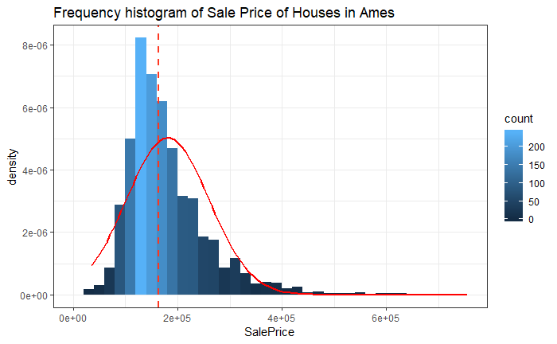

```r
p1
```

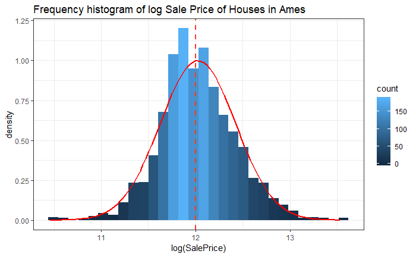

```r
#standarized
p2<-ggplot(train.comp,aes(x=log(SalePrice))) +
  geom_histogram(aes(y = ..density..,fill = ..count..))+
  stat_function(
    fun = dnorm,
    args = list(mean = mean(log(train.comp$SalePrice), na.rm = TRUE),
                sd = sd(log(train.comp$SalePrice), na.rm = TRUE)),
    lwd = 1,
    col = 'red'
    )+
    ggtitle("Frequency histogram of log Sale Price of Houses in Ames ")+
    theme_bw()+
    geom_vline(xintercept = median(log(train.comp$SalePrice)), size = 1, colour = "#FF3721",
                   linetype = "dashed")
p2
```

**The log(SalePrice) should be better.**

#### 1.2.4.2.Continuous variable

1.layout

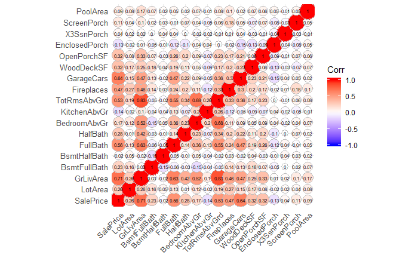

```r
vector.layout.c<-which(colnames(train.comp)=="LotArea"|
                        colnames(train.comp)=="GrLivArea"|
                        colnames(train.comp)=="BsmtFullBath"|
                        colnames(train.comp)=="BsmtHalfBath"|
                        colnames(train.comp)=="FullBath"|
                        colnames(train.comp)=="HalfBath"|
                        colnames(train.comp)=="BedroomAbvGr"|
                        colnames(train.comp)=="KitchenAbvGr"|
                        colnames(train.comp)=="TotRmsAbvGrd"|
                        colnames(train.comp)=="WoodDeckSF"|
                        colnames(train.comp)=="OpenPorchSF"|
                        colnames(train.comp)=="EnclosedPorch"|
                        colnames(train.comp)=="X3SsnPorch"|
                        colnames(train.comp)=="ScreenPorch"|
                        colnames(train.comp)=="Fireplaces"|
                        colnames(train.comp)=="GarageCars"|
                        colnames(train.comp)=="PoolArea")
#check the correlation for all the categorical variables between the time
df.time<-data.frame(train.comp[,c(80,vector.layout.c)])
df.time1 <-lapply(df.time,as.integer)#transform the categorical data into numeric
df.time1<-as.data.frame(df.time1)
corr.time <- round(cor(df.time1), 2)
library(ggcorrplot)
ggcorrplot(corr.time,method = "circle",lab=TRUE,tl.cex = 10,lab_size=2)
```

**The following predictors are important:5.LotArea,46.GrLivArea,56.Fireplaces,61.GarageCars, 66.WoodDeckSF,67.OpenPorchSF.**

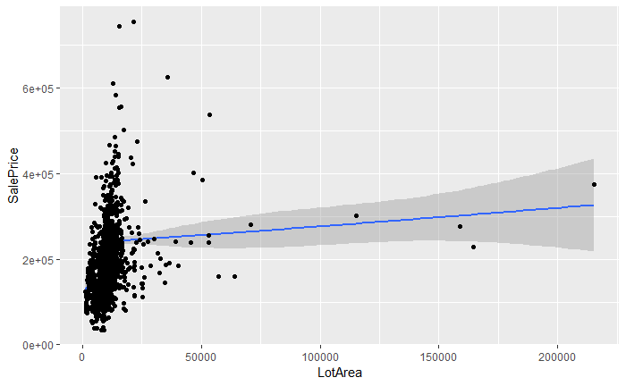

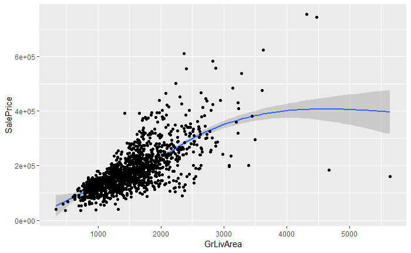

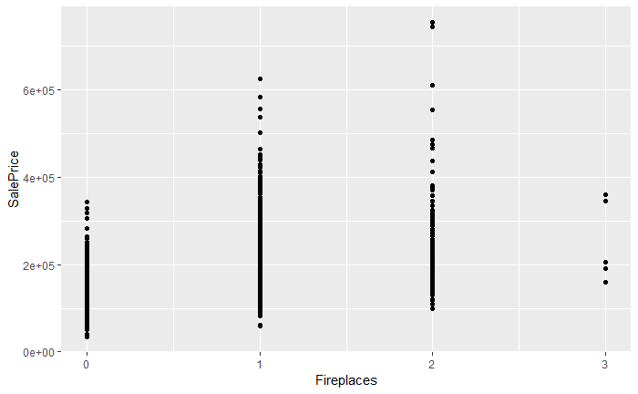

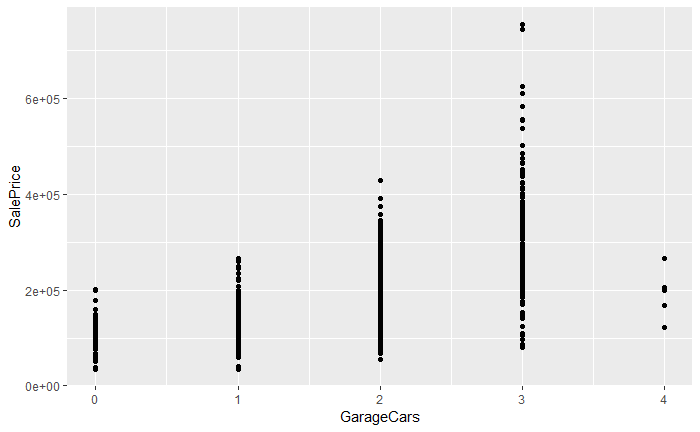

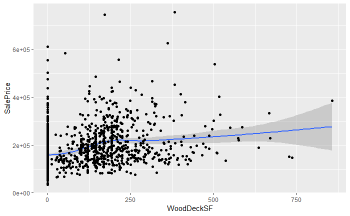

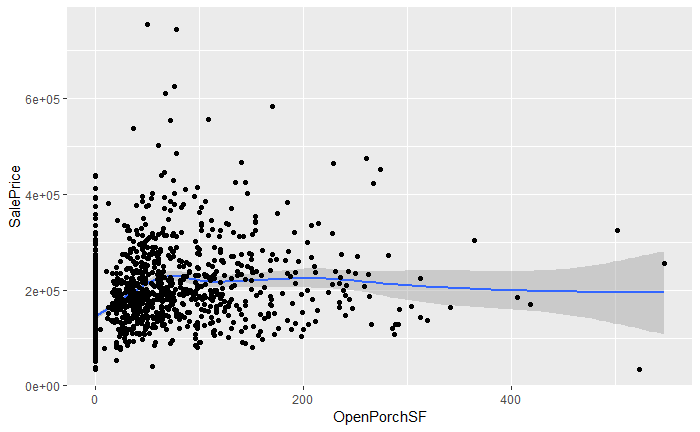

```r
vector.layout.c1<- c(5,46,56,61,66,67)
for (i in vector.layout.c1) {
  p1 <-ggplot(data = train.comp,
              aes(x = train.comp[,i], y = SalePrice)) +
              geom_smooth() + geom_point() +
              labs(y = "SalePrice", x = colnames(train.comp)[i])
  print(p1)
}
```

2.location

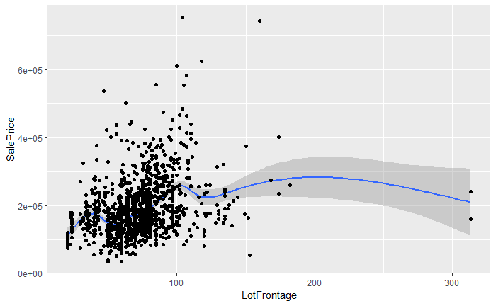

```r
p1 <-ggplot(data = train.comp,
              aes(x = train.comp[,4], y = SalePrice)) +
              geom_smooth() + geom_point() +
              labs(y = "SalePrice", x = colnames(train.comp)[4])
p1
```

3.quality

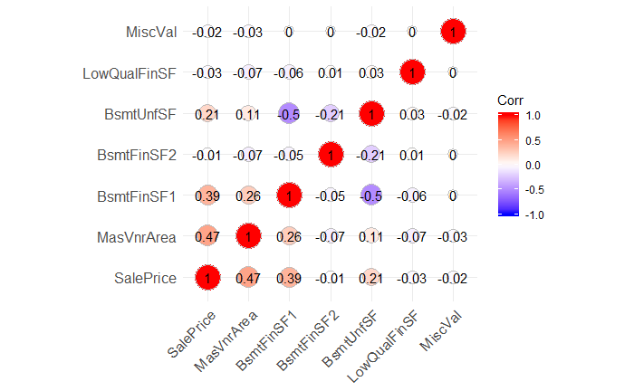

```r
vector.quality.c<-which(colnames(train.comp)=="MasVnrArea"|
                        colnames(train.comp)=="BsmtFinSF1"|
                        colnames(train.comp)=="BsmtFinSF2"|
                        colnames(train.comp)=="BsmtUnfSF"|
                        colnames(train.comp)=="LowQualFinSF"|
                        colnames(train.comp)=="MiscVal")
#check the correlation for all the categorical variables between the time
df.time<-data.frame(train.comp[,c(80,vector.quality.c)])
df.time1 <-lapply(df.time,as.integer)#transform the categorical data into numeric
df.time1<-as.data.frame(df.time1)
corr.time <- round(cor(df.time1), 2)
library(ggcorrplot)
ggcorrplot(corr.time,method = "circle",lab=TRUE)
```

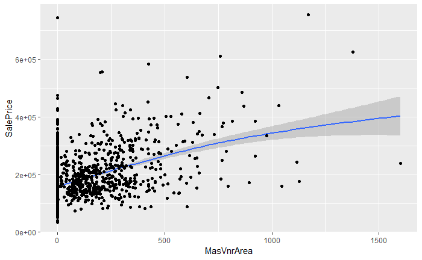

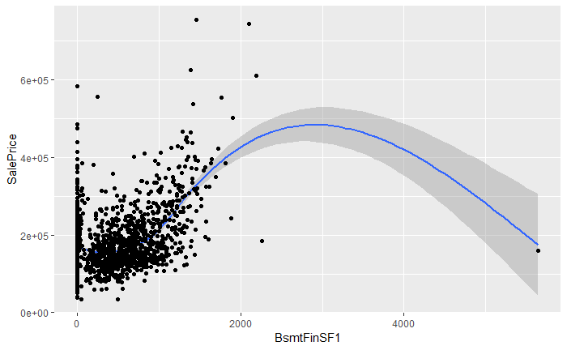

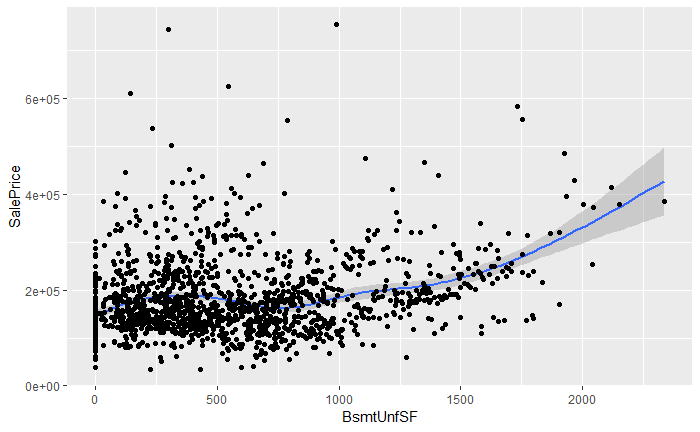

```r
vector.quality.c1<- c(26,34,37)
for (i in vector.quality.c1) {
  p1 <-ggplot(data = train.comp,
              aes(x = train.comp[,i], y = SalePrice)) +
              geom_smooth() + geom_point() +
              labs(y = "SalePrice", x = colnames(train.comp)[i])
  print(p1)
}
```

**26.MasVnrArea,34.BsmtFinSF1 and 37.BsmtUnfSF are important, but BsmtFinSF1 and BsmtUnfSF are highly correlated with TotalBsmtSF**

4.size

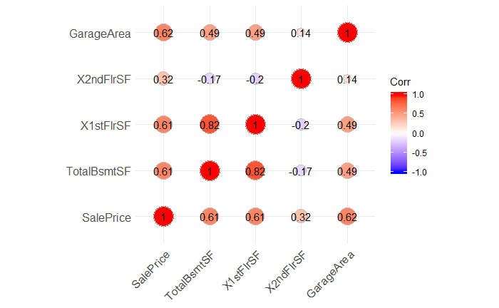

```r
vector.size<-c(38,43,44,62)
df.size<-data.frame(train.comp[,c(80,vector.size)])
df.size1<-as.data.frame(df.size)
corr.size <- round(cor(df.size1), 2)
library(ggcorrplot)
ggcorrplot(corr.size,method = "circle",lab=TRUE)
```

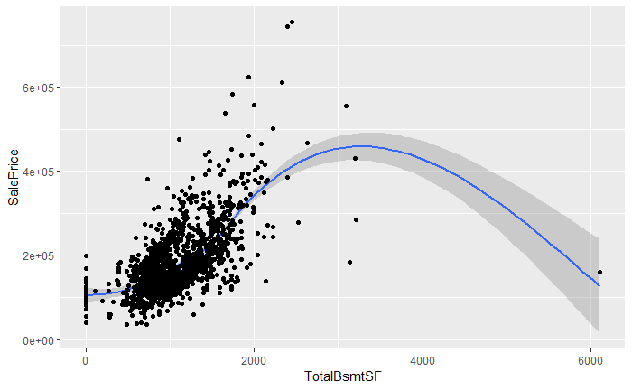

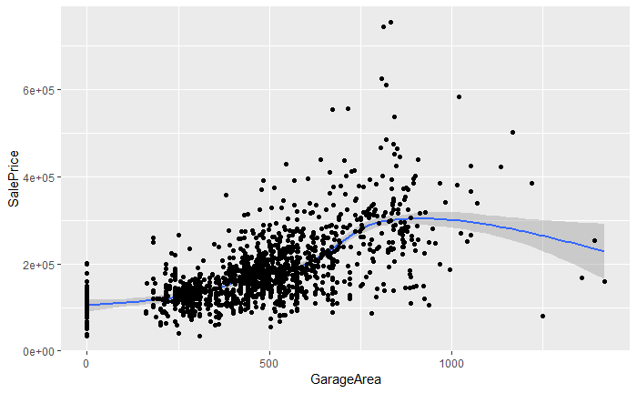

```r
vector.size1<- c(38,62)
for (i in vector.size1) {
  p1 <-ggplot(data = train.comp,
              aes(x = train.comp[,i], y = SalePrice)) +
              geom_smooth() + geom_point() +
              labs(y = "SalePrice", x = colnames(train.comp)[i])
  print(p1)
}
```

5.time

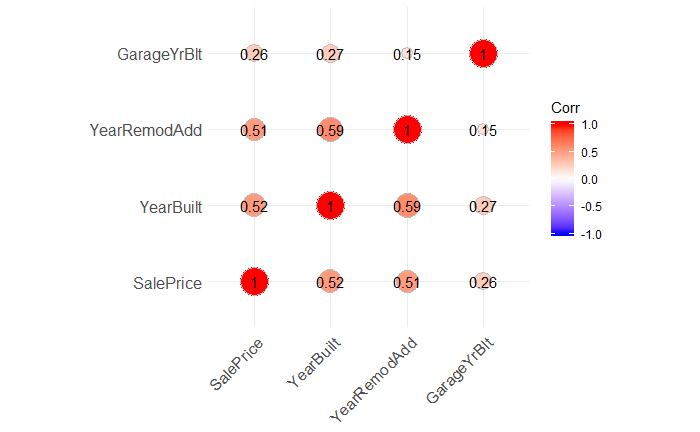

```r
vector.time<-which(colnames(train.comp)=="YearBuilt"|
                        colnames(train.comp)=="YearRemodAdd"|
                        colnames(train.comp)=="GarageYrBlt")
#check the correlation for all the categorical variables between the time
df.time<-data.frame(train.comp[,c(80,vector.time)])
df.time1 <-lapply(df.time,as.integer)#transform the categorical data into numeric
df.time1<-as.data.frame(df.time1)
corr.time <- round(cor(df.time1), 2)
library(ggcorrplot)
ggcorrplot(corr.time,method = "circle",lab=TRUE)
```

**Conclusion: 19.YearBuilt is important**

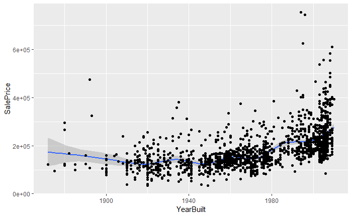

```r
vector.size1<-c(19)
for (i in vector.size1) {
  p1 <-ggplot(data = train.comp,
              aes(x = train.comp[,i], y = SalePrice)) +
              geom_smooth() + geom_point() +
              labs(y = "SalePrice", x = colnames(train.comp)[i])
  print(p1)
}
```

#### 1.2.3.3.Categorical variable

1.design

```r
#check the correlation for all the categorical variables between the design
vector.design<-which(colnames(train.comp)=="MSSubClass"|
                       colnames(train.comp)=="MSZoning"|
                       colnames(train.comp)=="LotShape"|
                       colnames(train.comp)=="LandContour"|
                       colnames(train.comp)=="LotConfig"|
                       colnames(train.comp)=="BldgType"|
                       colnames(train.comp)=="HouseStyle"|
                       colnames(train.comp)=="RoofStyle"|
                       colnames(train.comp)=="Foundation"|
                       colnames(train.comp)=="BsmtQual"|
                       colnames(train.comp)=="BsmtExposure")
summary(train.comp[,vector.design])
```

```
   MSSubClass     MSZoning    LotShape  LandContour   LotConfig      BldgType
 20     :536   C (all):  10   IR1:484   Bnk:  63    Corner : 263   1Fam  :1220
 60     :299   FV     :  65   IR2: 41   HLS:  50    CulDSac:  94   2fmCon:  31
 50     :144   RH     :  16   IR3: 10   Low:  36    FR2    :  47   Duplex:  52
 120    : 87   RL     :1151   Reg:925   Lvl:1311    FR3    :   4   Twnhs :  43
 30     : 69   RM     : 218                         Inside :1052   TwnhsE: 114
 160    : 63
 (Other):262
   HouseStyle    RoofStyle     Foundation      BsmtQual     BsmtExposure
 1Story :726   Flat   :  13   BrkTil:146   Ex      :121   Av      :221
 2Story :445   Gable  :1141   CBlock:634   Fa      : 35   Gd      :134
 1.5Fin :154   Gambrel:  11   PConc :647   Gd      :618   Mn      :114
 SLvl   : 65   Hip    : 286   Slab  : 24   TA      :649   No      :953
 SFoyer : 37   Mansard:   7   Stone :  6   NotExist: 37   NotExist: 38
 1.5Unf : 14   Shed   :   2   Wood  :  3
 (Other): 19
```

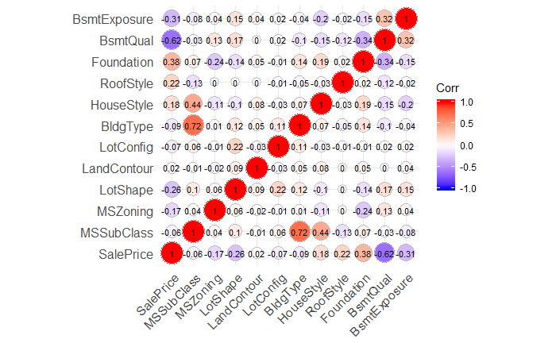

```r
df<-data.frame(train.comp[,c(80,vector.design)])
df1 <-lapply(df,as.integer)#transform the categorical data into numeric
df1<-as.data.frame(df1)
corr.design <- round(cor(df1), 2)
library(ggcorrplot)
ggcorrplot(corr.design,method = "circle",lab=TRUE,lab_size=3)
```

**Conclusion:The following predictors are important: 8.LotShape, 16.HouseStyle, 21.Roofstyle, 29.Foundtation, 30.BsmtQual, 32.BsmtExposure**

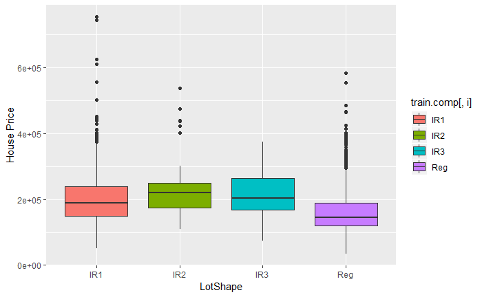

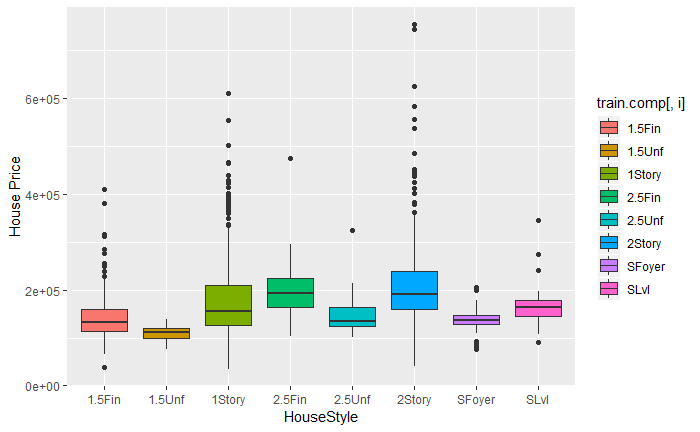

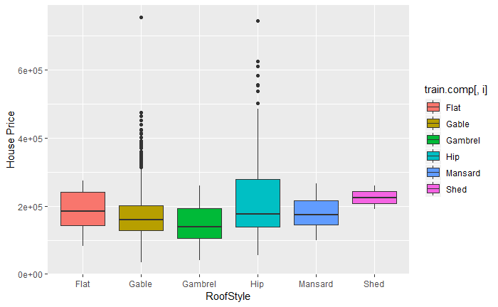

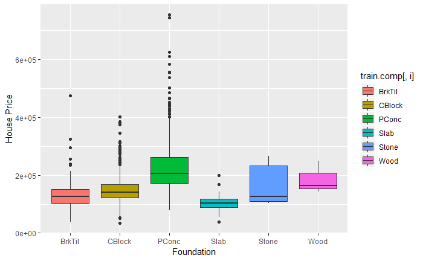

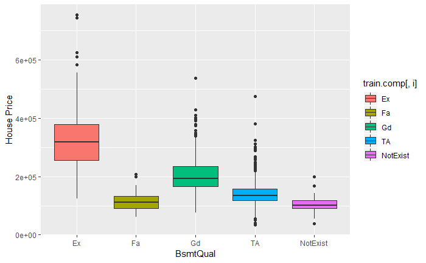

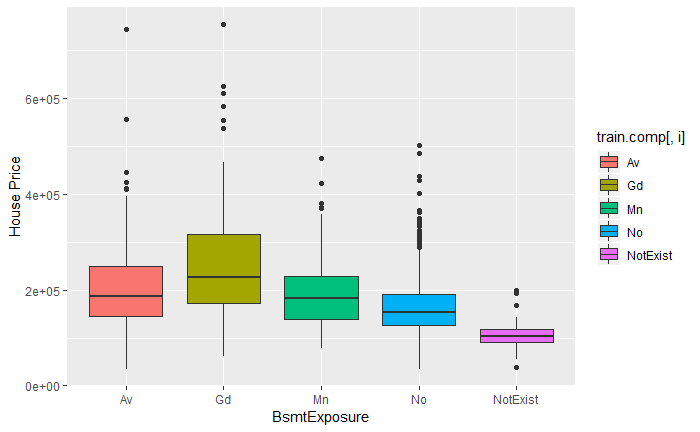

```r
#plot the boxplot for possible predictor
vector.design1<-c(8,16,21,29,30,32)
for (i in vector.design1){
  p.design<-ggplot(data=train.comp,
                   aes(x=train.comp[,i],y=SalePrice,fill=train.comp[,i]))+
                   geom_boxplot()+
                  labs(y="House Price",x=colnames(train.comp)[i])
  print (p.design)
}
```

2.equipment

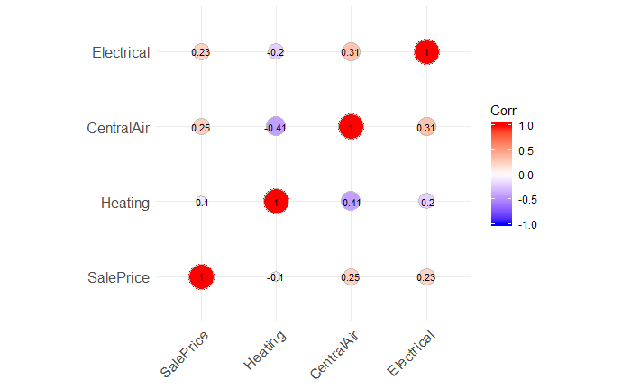

```r
#check the correlation for all the categorical variables between the equipment
#cor(is.na(house.train[,43]),house.train[,81])#uncorrelated
vector.equipment<-which(colnames(train.comp)=="Heating"|
                       colnames(train.comp)=="CentralAir"|
                       colnames(train.comp)=="Electrical")
df<-data.frame(train.comp[,c(80,vector.equipment)])
df1 <-lapply(df,as.integer)#transform the categorical data into numeric
df1<-as.data.frame(df1)
corr.equipment <- round(cor(df1), 2)
library(ggcorrplot)
ggcorrplot(corr.equipment,method = "circle",lab=TRUE,lab_size=3)
```